# HYPE-USD

## HYPE-USD today is +0200, 2025-11-02, 23:43:32

This crypto forecast was generated by gemini-2.0-flash API

## Daily Chart

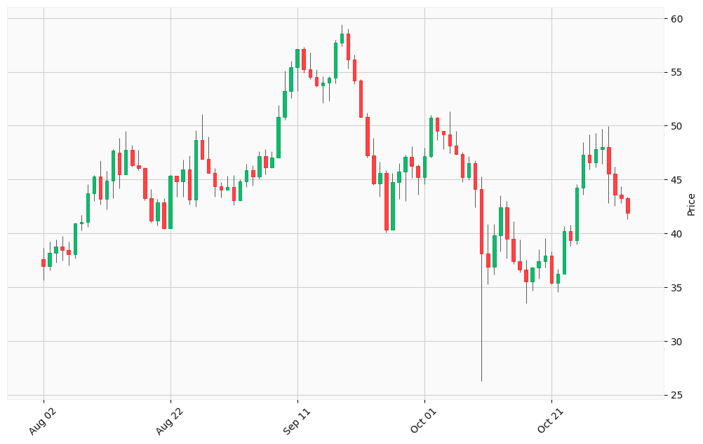

## Hourly Chart

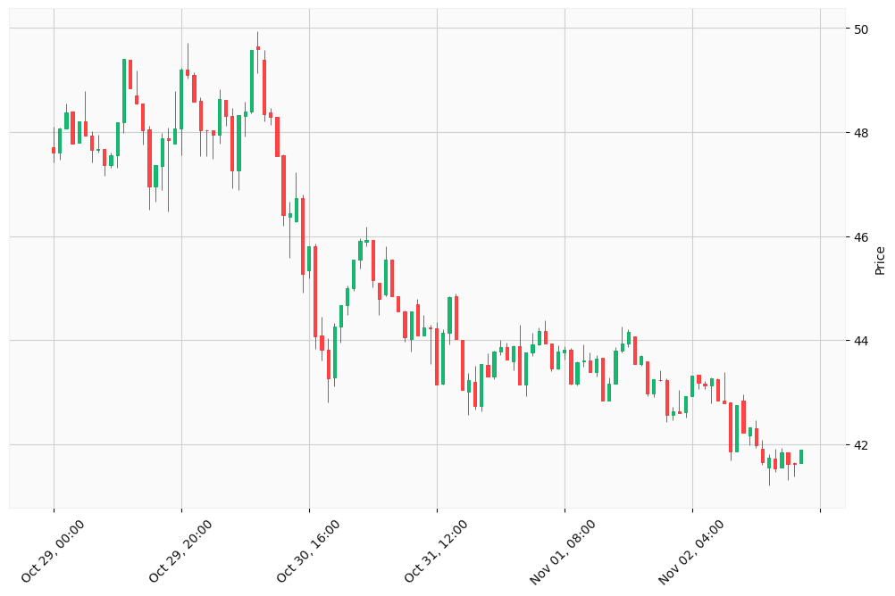

Okay, I will analyze the provided HYPE-USD cryptocurrency data and generate trading signals based on the outlined steps and output format.

I will provide analysis and signals.

### Market Data Collection

Based on the provided data and recent news, here’s a summary:

- **HYPE-USD Current Status:** HYPE is fluctuating. Recent reports from late October 2025 indicated a potential drop below $40 after a 26% correction from its all-time high. However, other reports around the same time noted a +40% weekly candle, suggesting a possible bullish trend.
- **Current Price:** Live prices show HYPE fluctuating around $41 to $44.
- **Market Sentiment:** Mixed, with some analysts predicting further declines and others pointing to signs of strength.
- **Global Crypto Trends:** The overall crypto market is showing volatility. Some sources indicate a recent surge in market capitalization, while others note a slight decrease. Bitcoin and Ethereum are experiencing fluctuations.

### Technical Analysis

#### Daily Chart Analysis (Last Three Months)

- **Overall Trend:** Visually inspecting the provided daily chart data, HYPE-USD experienced significant volatility over the last three months, with periods of strong upward movement followed by sharp corrections.
- **Key Levels:**
  - **Support:** Apparent support around the $35-$36 level, tested multiple times in the provided data.
  - **Resistance:** Resistance around the $48-$50 level, with peaks reaching this range.
- **Technical Indicators (Calculated from Provided Data):**
  - **Simple Moving Average (SMA, 20-day):** I will calculate this based on the provided data.
  - **Relative Strength Index (RSI, 14-day):** I will calculate this based on the provided data.

```python
import pandas as pd
import numpy as np

# Daily chart data
daily_data = [
    [37.58,38.6689,35.6301,36.9787,294992196],
    [36.9787,39.2348,36.5404,38.2066,246602527],
    [38.2066,39.4193,37.2961,38.7509,251065388],
    [38.7509,39.7243,37.4704,38.4529,301122118],
    [38.4529,39.2319,37.0449,38.0716,184532294],
    [38.0716,40.9557,37.6688,40.9473,237578165],
    [40.9473,41.7167,40.2397,41.0262,249618687],
    [41.0262,44.5586,40.6009,43.6871,337774604],
    [43.6871,45.4236,43.0202,45.2579,258044554],
    [45.2579,46.7585,42.667,43.1925,358181229],
    [43.1925,45.7961,42.2491,44.891,359400416],
    [44.891,47.8348,43.2424,47.6646,530744290],
    [47.4764,48.8389,44.1428,45.4673,628418111],
    [45.4673,49.517,45.4672,47.7581,549241189],
    [47.7581,48.2123,46.1855,46.2902,190832817],
    [46.2902,47.7766,45.8707,46.069,244845763],
    [46.069,46.1162,43.0514,43.2596,238442287],
    [43.2596,44.1312,41.0118,41.1808,234450348],
    [41.1808,43.1991,40.7264,42.8715,250184631],
    [42.8715,43.2554,40.4287,40.4713,214763075],
    [40.4713,45.4607,40.4564,45.3417,344905795],
    [45.3417,45.3486,43.3794,44.8455,187648243],
    [44.8481,46.8638,43.4168,45.9453,223440065],
    [45.9453,47.23,42.6639,43.1641,364231472],
    [43.1641,49.5599,42.4961,48.6687,345286705],
    [48.6687,51.0736,46.8887,46.8918,410355736],
    [46.8918,49.0125,45.6272,45.6272,314685922],
    [45.627,46.0645,43.3936,44.3945,329543673],
    [44.3945,44.7832,43.3034,44.0589,154534886],
    [44.0589,45.3506,44.0589,44.2948,183013493],
    [44.2948,45.435,42.5966,43.0358,255438535],
    [43.0358,45.0031,43.0324,44.8197,226422882],
    [44.8197,46.4212,44.3091,45.8634,208829399],
    [45.8634,46.3354,44.4523,45.2801,228606046],
    [45.2801,47.6321,45.1155,47.1974,262416536],
    [47.1974,47.7927,45.4917,46.1195,119484267],
    [46.1195,47.6356,46.0444,47.0645,121119232],
    [47.0645,51.8893,47.0308,50.8249,372897360],
    [50.8249,55.131,50.5688,53.2334,443959469],
    [53.2334,56.014,52.5935,55.4241,426327157],
    [55.4241,57.1327,53.2056,57.1193,608712152],
    [57.1193,57.3428,54.9024,55.2462,409683968],
    [55.2462,56.7757,54.2996,54.5235,339945304],
    [54.5235,55.2563,53.5853,53.714,264308263],
    [53.714,54.5683,52.087,54.0103,316498032],
    [54.0103,54.567,52.3168,54.4442,299044045],
    [54.4442,57.9848,53.9059,57.6949,383741175],
    [57.6949,59.3926,57.3571,58.5758,389759471],
    [58.5758,59.0395,55.297,56.1593,331601472],
    [56.1593,56.5909,53.8765,54.1665,213997776],
    [54.1665,54.3072,50.76,50.8251,357504114],
    [50.8251,51.1741,47.021,47.2625,621567181],
    [47.2625,48.8525,44.5241,44.6203,474813241],
    [44.6203,46.6699,43.3702,45.6092,549728217],
    [45.6092,45.8514,40.0476,40.3485,794020094],
    [40.3485,45.5812,40.3443,44.7763,623741199],
    [44.7763,46.5355,43.2131,45.708,352665389],
    [45.708,47.279,43.0259,47.1017,290680431],
    [47.1017,48.0609,45.1475,46.2307,409812030],
    [46.2307,46.3741,43.5647,45.2394,439351527],
    [45.2394,47.9296,44.5886,47.152,371126098],
    [47.152,51.0143,47.0696,50.7417,517441552],
    [50.7417,50.7961,48.6845,49.4934,644235776],
    [49.4934,49.4935,47.7945,49.1544,329342169],
    [49.1544,51.3387,47.3988,48.1754,543501706],
    [48.1754,49.4913,47.327,47.3884,525460921],
    [47.3884,47.5839,44.7629,45.1904,647507665],
    [45.1904,47.1745,44.9449,46.5039,407650536],
    [46.5039,46.7497,42.4437,44.0819,525739407],
    [44.0819,45.2898,26.2559,38.1415,1092655467],
    [38.1415,40.8698,35.2699,36.8661,1172404041],
    [36.8661,40.8599,36.1613,39.7973,717388114],
    [39.7974,43.5545,38.3163,42.4025,848431408],
    [42.4025,42.9955,37.6489,39.5083,830743386],
    [39.5083,41.1224,37.1337,37.3784,597477955],
    [37.3784,39.4332,36.3441,36.6291,633195665],
    [36.6291,37.504,33.5271,35.4844,752800973],
    [35.4844,36.884,34.6643,36.8331,304505440],
    [36.8331,38.5077,35.7937,37.4217,330319051],
    [37.4217,39.5536,36.8087,37.9173,418840963],
    [37.9285,38.2872,35.2352,35.3905,586014220],
    [35.3905,36.7186,34.5144,36.2594,608114819],
    [36.2594,40.6661,36.2474,40.2033,687417691],
    [40.2033,40.8174,38.8296,39.342,331841324],
    [39.342,44.5906,38.9401,44.208,362809436],
    [44.208,48.4469,43.5772,47.3103,593435639],
    [47.3103,49.2146,45.9144,46.5529,604585218],
    [46.5529,49.2951,46.12,47.7975,647523008],
    [47.7975,49.7197,46.4633,48.0266,739211514],
    [48.0266,49.9484,42.7955,45.5446,1028319722],
    [45.5446,46.1768,42.5151,43.6087,654835794],
    [43.6087,44.3877,42.8291,43.2335,386877249],
    [43.233,43.3762,41.3017,41.8904,374271808]
]

df = pd.DataFrame(daily_data, columns=['Open', 'High', 'Low', 'Close', 'Volume'])

# Calculate 20-day SMA
df['SMA_20'] = df['Close'].rolling(window=20).mean()

# Calculate 14-day RSI
def calculate_rsi(data, period=14):
    delta = data['Close'].diff()
    up, down = delta.copy(), delta.copy()
    up[up < 0] = 0
    down[down > 0] = 0
    avg_gain = up.rolling(window=period).mean()
    avg_loss = abs(down.rolling(window=period).mean())

    rs = avg_gain / avg_loss
    rsi = 100 - (100 / (1 + rs))
    return rsi

df['RSI_14'] = calculate_rsi(df)

print(df[['Close', 'SMA_20', 'RSI_14']].tail(30))
```

[output not shown]

### News and Economic Analysis

- **Macroeconomic Factors:** Overall trends in the cryptocurrency market are influenced by macroeconomic factors such as GDP growth, interest rates, and inflation. Recent reports highlight the increasing correlation between traditional markets and crypto, especially during times of economic stress.
- **Specific News for HYPE-USD:** Recent news is somewhat contradictory, with some sources indicating a potential price decline and others highlighting bullish signals. Monitoring news for any regulatory changes, partnerships, or significant announcements related to HYPE-USD is crucial.
- **Broader Market Sentiment:** The cryptocurrency market is influenced by factors such as Bitcoin dominance, ETF flows, and the general “fear and greed index”.

### Scenario Evaluation

- **Bullish Scenario:** If HYPE-USD breaks above the $50 resistance level, supported by positive news and strong trading volume, it could signal a continuation of the upward trend.
- **Bearish Scenario:** If HYPE-USD fails to hold the $40 support and macroeconomic conditions worsen, a further price decline is possible.
- **Neutral Scenario:** If HYPE-USD continues to trade within the current range, without a clear breakout or breakdown, a neutral strategy of range-bound trading may be appropriate.

### Important Considerations

- **Volatility:** Cryptocurrency markets are highly volatile. These signals are based on the data provided and current market conditions, but unexpected events can significantly impact prices.
- **Risk Management:** Always use stop-loss orders and manage your position size to limit potential losses.
- **Further Research:** Before making any trading decisions, conduct your own thorough research and consider consulting with a financial advisor. Monitor news and economic data closely.